# **Predicting the Sales of Steam Games**

Liam McCarthy

**Introduction**

Welcome to this tutorial on the data science pipeline! Data science is the interdisciplinary field that combines statistics and computer science to extract insights and knowledge from data. The objective of this tutorial is to predict the sales of a Steam game.

In order to accomplish this goal we will need to use the data science pipeline. The five stages of the data science pipeline are data collection, data processing, exploratory analysis, hypothesis testing/machine learning, and insight.

First, data collection, is where data is gathered from various sources such as databases, web scraping, surveys, or sensors. This is when we will get the data for the Steam games as well as any other data we need. When collecting data for your own data science project it is important to ensure the data you want to use is suitable for your project. This is because using improper data will accuracy and reliability of the results.

The second stage is data processing, where the collected data is cleaned, organized, and prepared for analysis. This stage includes tasks such as removing duplicates, handling missing values, and transforming the data into a usable format for analysis.

The third stage is exploratory analysis, where data visualization and descriptive statistics are used to understand the structure and characteristics of the data. This stage is essential in identifying patterns, relationships, and outliers in the data, which can inform subsequent analysis.

The fourth stage is hypothesis testing and machine learning, where a machine learning model is developed in order to test hypotheses, make predictions, or classify data. This stage can involve complex algorithms and models that require expertise in statistics, mathematics, and computer science. Don't worry though the model used in this tutorial will be relatively simple.

The final stage is insight, where the results of the analysis are translated into actionable insights that can inform decision-making. This stage is crucial for communicating the findings of the analysis to stakeholders and making recommendations for future actions.

As said above the goal of the tutorial is to walk you through the data science pipeline and create a model that can predict the sales of a Steam game. We could use this model to see what kinds of games make the most profit, what effect the price of a game has on sales, and which developers and publishers make the most profitable games.

```python
#Imports
import pandas as pd
import numpy as np
from datetime import datetime
import matplotlib.pyplot as plt
from scipy.stats import zscore
from sklearn.model_selection import train_test_split
from sklearn.preprocessing import OneHotEncoder
import tensorflow as tf
from keras.models import Sequential
from keras.layers import Dense
```

**Data Collection**

To start off this tutorial we have to read in our data. We will be using this, https://www.kaggle.com/datasets/nikdavis/steam-store-games, dataset from Kaggle. This dataset was scraped from the Steam store and SteamSpy API. This dataset contains data on a game's price, developer, publisher, and tags. We will use the pandas library to read in the data from a CSV file.

```python
#Read in data from csv file
steam_df = pd.read_csv('/content/steam.csv')
steam_df.head()
```

|  | appid | name | release_date | english | developer | publisher | platforms | required_age | categories | genres | steamspy_tags | achievements | positive_ratings | negative_ratings | average_playtime | median_playtime | owners | price |
| --- | --- | --- | --- | --- | --- | --- | --- | --- | --- | --- | --- | --- | --- | --- | --- | --- | --- | --- |
| 0 | 10 | Counter-Strike | 2000-11-01 | 1 | Valve | Valve | windows;mac;linux | 0 | Multi-player;Online Multi-Player;Local Multi-P... | Action | Action;FPS;Multiplayer | 0 | 124534 | 3339 | 17612 | 317 | 10000000-20000000 | 7.19 |
| 1 | 20 | Team Fortress Classic | 1999-04-01 | 1 | Valve | Valve | windows;mac;linux | 0 | Multi-player;Online Multi-Player;Local Multi-P... | Action | Action;FPS;Multiplayer | 0 | 3318 | 633 | 277 | 62 | 5000000-10000000 | 3.99 |
| 2 | 30 | Day of Defeat | 2003-05-01 | 1 | Valve | Valve | windows;mac;linux | 0 | Multi-player;Valve Anti-Cheat enabled | Action | FPS;World War II;Multiplayer | 0 | 3416 | 398 | 187 | 34 | 5000000-10000000 | 3.99 |
| 3 | 40 | Deathmatch Classic | 2001-06-01 | 1 | Valve | Valve | windows;mac;linux | 0 | Multi-player;Online Multi-Player;Local Multi-P... | Action | Action;FPS;Multiplayer | 0 | 1273 | 267 | 258 | 184 | 5000000-10000000 | 3.99 |
| 4 | 50 | Half-Life: Opposing Force | 1999-11-01 | 1 | Gearbox Software | Valve | windows;mac;linux | 0 | Single-player;Multi-player;Valve Anti-Cheat en... | Action | FPS;Action;Sci-fi | 0 | 5250 | 288 | 624 | 415 | 5000000-10000000 | 3.99 |

There is a problem, in order to create a model that can predict the sales of a Steam game we need a game's sales data. However, the dataset from Kaggle is missing the games sales data. So we will need augment the dataframe with the data from a different dataset. We will use sales data from this dataset, https://data.world/mhoangvslev/steam-games-dataset. Again we will use the pandas library to read in the data from a CSV file.

```python
#Read in data from CSV file
sales_df = pd.read_csv('/content/vgsales.csv')
sales_df = sales_df.rename(columns={'Name': 'name'})
sales_df = sales_df.rename(columns={'Year_of_Release': 'Year'})
sales_df.head()
```

|  | name | Platform | Year | Genre | Publisher | NA_Sales | EU_Sales | JP_Sales | Other_Sales | Global_Sales | Critic_Score | Critic_Count | User_Score | User_Count | Developer | Rating |
| --- | --- | --- | --- | --- | --- | --- | --- | --- | --- | --- | --- | --- | --- | --- | --- | --- |
| 0 | Wii Sports | Wii | 2006.0 | Sports | Nintendo | 41.36 | 28.96 | 3.77 | 8.45 | 82.53 | 76.0 | 51.0 | 8 | 322.0 | Nintendo | E |
| 1 | Super Mario Bros. | NES | 1985.0 | Platform | Nintendo | 29.08 | 3.58 | 6.81 | 0.77 | 40.24 | NaN | NaN | NaN | NaN | NaN | NaN |
| 2 | Mario Kart Wii | Wii | 2008.0 | Racing | Nintendo | 15.68 | 12.76 | 3.79 | 3.29 | 35.52 | 82.0 | 73.0 | 8.3 | 709.0 | Nintendo | E |
| 3 | Wii Sports Resort | Wii | 2009.0 | Sports | Nintendo | 15.61 | 10.93 | 3.28 | 2.95 | 32.77 | 80.0 | 73.0 | 8 | 192.0 | Nintendo | E |
| 4 | Pokemon Red/Pokemon Blue | GB | 1996.0 | Role-Playing | Nintendo | 11.27 | 8.89 | 10.22 | 1.00 | 31.37 | NaN | NaN | NaN | NaN | NaN | NaN |

**Data Processing**

Now that we have collected the data that we need it is now time to move on to the second step in the data science pipeline. The first thing that we should do is merge the steam dataframe and sales dataframe into a single master dataframe. There are several ways of joining two dataframes but for our purposes here we will be using an inner join. This is because the sales dataframe has data for more games than just Steam games. Doing an inner join will get all of the data for just Steam games from both datasets and create a master database that we will be using for the rest of this tutorial. If you are interested in the other types of joins more information can be found here, https://www.thedataschool.co.uk/harry-cooney/what-are-data-joins/.

```python
df = pd.merge(steam_df, sales_df, on='name')
df.head()
```

|  | appid | name | release_date | english | developer | publisher | platforms | required_age | categories | genres | ... | EU_Sales | JP_Sales | Other_Sales | Global_Sales | Critic_Score | Critic_Count | User_Score | User_Count | Developer | Rating |
| --- | --- | --- | --- | --- | --- | --- | --- | --- | --- | --- | --- | --- | --- | --- | --- | --- | --- | --- | --- | --- | --- |
| 0 | 10 | Counter-Strike | 2000-11-01 | 1 | Valve | Valve | windows;mac;linux | 0 | Multi-player;Online Multi-Player;Local Multi-P... | Action | ... | 0.23 | 0.00 | 0.04 | 1.11 | 74.0 | 38.0 | 7.6 | 51.0 | Valve Software | M |
| 1 | 70 | Half-Life | 1998-11-08 | 1 | Valve | Valve | windows;mac;linux | 0 | Single-player;Multi-player;Online Multi-Player... | Action | ... | 0.00 | 0.09 | 0.00 | 4.12 | 96.0 | 24.0 | 9.1 | 3161.0 | Valve Software | M |
| 2 | 70 | Half-Life | 1998-11-08 | 1 | Valve | Valve | windows;mac;linux | 0 | Single-player;Multi-player;Online Multi-Player... | Action | ... | 0.23 | 0.00 | 0.08 | 0.60 | 87.0 | 24.0 | 8.6 | 94.0 | Gearbox Software | M |
| 3 | 220 | Half-Life 2 | 2004-11-16 | 1 | Valve | Valve | windows;mac;linux | 0 | Single-player;Steam Achievements;Steam Trading... | Action | ... | 0.02 | 0.08 | 0.00 | 2.37 | 96.0 | 81.0 | 9.1 | 8665.0 | Valve Software | M |
| 4 | 220 | Half-Life 2 | 2004-11-16 | 1 | Valve | Valve | windows;mac;linux | 0 | Single-player;Steam Achievements;Steam Trading... | Action | ... | 0.21 | 0.00 | 0.03 | 0.61 | 90.0 | 35.0 | 8.6 | 115.0 | Valve Software | M |

5 rows × 33 columns

Now that we have our master dataset it is time to tidy the data. The first thing we can do is remove any duplicate columns or columns we won't need. Then we need to drop all rows that contain NaN values.

```python
#First remove all uneeded columns
df.drop('Platform', axis=1, inplace=True)
df.drop('Genre', axis=1, inplace=True)
df.drop('Publisher', axis=1, inplace=True)
df.drop('Developer', axis=1, inplace=True)
df.drop('Critic_Score', axis=1, inplace=True)
df.drop('User_Score', axis=1, inplace=True)
df.drop('Critic_Count', axis=1, inplace=True)
df.drop('User_Count', axis=1, inplace=True)
df.drop('steamspy_tags', axis=1, inplace=True)

#Drop NaN values
df.dropna()

df.head()
```

|  | appid | name | release_date | english | developer | publisher | platforms | required_age | categories | genres | ... | median_playtime | owners | price | Year | NA_Sales | EU_Sales | JP_Sales | Other_Sales | Global_Sales | Rating |
| --- | --- | --- | --- | --- | --- | --- | --- | --- | --- | --- | --- | --- | --- | --- | --- | --- | --- | --- | --- | --- | --- |
| 0 | 10 | Counter-Strike | 2000-11-01 | 1 | Valve | Valve | windows;mac;linux | 0 | Multi-player;Online Multi-Player;Local Multi-P... | Action | ... | 317 | 10000000-20000000 | 7.19 | 2003.0 | 0.85 | 0.23 | 0.00 | 0.04 | 1.11 | M |
| 1 | 70 | Half-Life | 1998-11-08 | 1 | Valve | Valve | windows;mac;linux | 0 | Single-player;Multi-player;Online Multi-Player... | Action | ... | 83 | 5000000-10000000 | 7.19 | 1997.0 | 4.03 | 0.00 | 0.09 | 0.00 | 4.12 | M |
| 2 | 70 | Half-Life | 1998-11-08 | 1 | Valve | Valve | windows;mac;linux | 0 | Single-player;Multi-player;Online Multi-Player... | Action | ... | 83 | 5000000-10000000 | 7.19 | 2001.0 | 0.29 | 0.23 | 0.00 | 0.08 | 0.60 | M |
| 3 | 220 | Half-Life 2 | 2004-11-16 | 1 | Valve | Valve | windows;mac;linux | 0 | Single-player;Steam Achievements;Steam Trading... | Action | ... | 402 | 10000000-20000000 | 7.19 | 2004.0 | 2.28 | 0.02 | 0.08 | 0.00 | 2.37 | M |
| 4 | 220 | Half-Life 2 | 2004-11-16 | 1 | Valve | Valve | windows;mac;linux | 0 | Single-player;Steam Achievements;Steam Trading... | Action | ... | 402 | 10000000-20000000 | 7.19 | 2005.0 | 0.37 | 0.21 | 0.00 | 0.03 | 0.61 | M |

5 rows × 24 columns

The next thing we need to do in order to tidy the data is to create columns for each tag that will be used for analysis. We want to create a column that will contain a boolean that tells us whether the game is multiplayer or not. Additionally, we will want to split the platform column into a separate column for each platform. Don't forget to remove the now defunct platform column.

```python
#Create multiplayer column from steamspy_tags
df["multiplayer"] = df['categories'].apply(lambda x: "Multi-player" in x)
#Split platforms into separate columns from platform tags
df["windows"] = df['platforms'].apply(lambda x: "windows" in x)
df["mac"] = df['platforms'].apply(lambda x: "mac" in x)
df["linux"] = df['platforms'].apply(lambda x: "linux" in x)
#Remove platforms column
df.drop('platforms', axis=1, inplace=True)
```

The release_date column is the next thing that needs to be cleaned in our dataset. Currently, it contains a string describing the release date. This will not work later when we are trying to create plots. So to fix this we will need to convert the strings into datetime objects using the datetime library.

```python
#Iterate over the rows of the dataframe converting strings into datetime objects
for i, row in df.iterrows():
  date = row['release_date']
  df.at[i, 'release_date'] = datetime.strptime(date, '%Y-%m-%d')
df.head()
```

|  | appid | name | release_date | english | developer | publisher | required_age | categories | genres | achievements | ... | NA_Sales | EU_Sales | JP_Sales | Other_Sales | Global_Sales | Rating | multiplayer | windows | mac | linux |
| --- | --- | --- | --- | --- | --- | --- | --- | --- | --- | --- | --- | --- | --- | --- | --- | --- | --- | --- | --- | --- | --- |
| 0 | 10 | Counter-Strike | 2000-11-01 00:00:00 | 1 | Valve | Valve | 0 | Multi-player;Online Multi-Player;Local Multi-P... | Action | 0 | ... | 0.85 | 0.23 | 0.00 | 0.04 | 1.11 | M | True | True | True | True |
| 1 | 70 | Half-Life | 1998-11-08 00:00:00 | 1 | Valve | Valve | 0 | Single-player;Multi-player;Online Multi-Player... | Action | 0 | ... | 4.03 | 0.00 | 0.09 | 0.00 | 4.12 | M | True | True | True | True |
| 2 | 70 | Half-Life | 1998-11-08 00:00:00 | 1 | Valve | Valve | 0 | Single-player;Multi-player;Online Multi-Player... | Action | 0 | ... | 0.29 | 0.23 | 0.00 | 0.08 | 0.60 | M | True | True | True | True |
| 3 | 220 | Half-Life 2 | 2004-11-16 00:00:00 | 1 | Valve | Valve | 0 | Single-player;Steam Achievements;Steam Trading... | Action | 33 | ... | 2.28 | 0.02 | 0.08 | 0.00 | 2.37 | M | False | True | True | True |
| 4 | 220 | Half-Life 2 | 2004-11-16 00:00:00 | 1 | Valve | Valve | 0 | Single-player;Steam Achievements;Steam Trading... | Action | 33 | ... | 0.37 | 0.21 | 0.00 | 0.03 | 0.61 | M | False | True | True | True |

5 rows × 27 columns

In order to make it easier to use the steam ratings we will be combining the postive ratings and the negative ratings into two columns called Steam_Score and Steam_Count.

To find the Steam_Score we will be using this formula:

T = (P / (P+N))*100

where P is the number of positive ratings and N is the number of negative ratings. Steam_count is the total number of ratings a game has recevied.

```python
#Create Steam column using formula
df['Steam_Score'] = (df['positive_ratings']/(df['positive_ratings'] + df['negative_ratings']))*100
df['Steam_Count'] = df['positive_ratings'] + df['negative_ratings']
#Remove positive and negative ratings columns
df.drop('positive_ratings', axis=1, inplace=True)
df.drop('negative_ratings', axis=1, inplace=True)
df.head()
```

|  | appid | name | release_date | english | developer | publisher | required_age | categories | genres | achievements | ... | JP_Sales | Other_Sales | Global_Sales | Rating | multiplayer | windows | mac | linux | Steam_Score | Steam_Count |
| --- | --- | --- | --- | --- | --- | --- | --- | --- | --- | --- | --- | --- | --- | --- | --- | --- | --- | --- | --- | --- | --- |
| 0 | 10 | Counter-Strike | 2000-11-01 00:00:00 | 1 | Valve | Valve | 0 | Multi-player;Online Multi-Player;Local Multi-P... | Action | 0 | ... | 0.00 | 0.04 | 1.11 | M | True | True | True | True | 97.388815 | 127873 |
| 1 | 70 | Half-Life | 1998-11-08 00:00:00 | 1 | Valve | Valve | 0 | Single-player;Multi-player;Online Multi-Player... | Action | 0 | ... | 0.09 | 0.00 | 4.12 | M | True | True | True | True | 96.187836 | 28855 |
| 2 | 70 | Half-Life | 1998-11-08 00:00:00 | 1 | Valve | Valve | 0 | Single-player;Multi-player;Online Multi-Player... | Action | 0 | ... | 0.00 | 0.08 | 0.60 | M | True | True | True | True | 96.187836 | 28855 |
| 3 | 220 | Half-Life 2 | 2004-11-16 00:00:00 | 1 | Valve | Valve | 0 | Single-player;Steam Achievements;Steam Trading... | Action | 33 | ... | 0.08 | 0.00 | 2.37 | M | False | True | True | True | 96.560060 | 70321 |
| 4 | 220 | Half-Life 2 | 2004-11-16 00:00:00 | 1 | Valve | Valve | 0 | Single-player;Steam Achievements;Steam Trading... | Action | 33 | ... | 0.00 | 0.03 | 0.61 | M | False | True | True | True | 96.560060 | 70321 |

5 rows × 27 columns

**Exploratory analysis and & Data visualization**

Now that were are done with the data collection and processing steps we can move on to the fun stuff. It is now time to start exploring our data and the relationships the variables have with each other. The goal of this step is to find what variables have an impact on the sales of a game.

First lets see if there is a relationship between the steam score and sales for each region. To do this we will be creating scatterplots for each region using matplotlib.

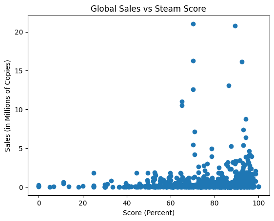

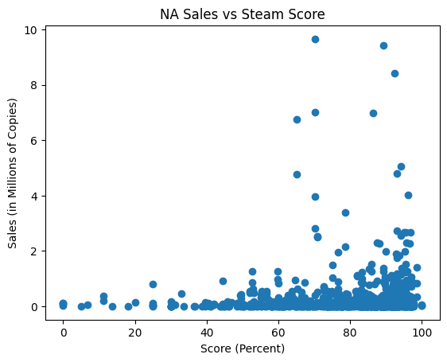

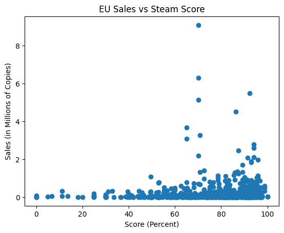

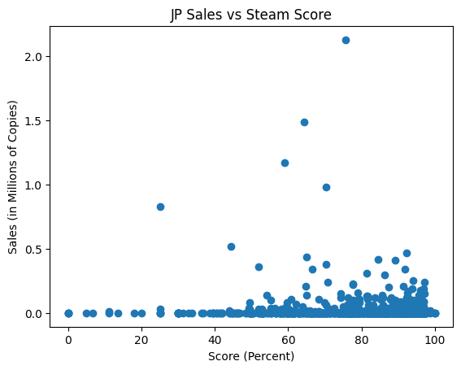

```python
#Plot global information
plt.scatter(df['Steam_Score'], df['Global_Sales'])
plt.ylabel('Sales (in Millions of Copies)')
plt.xlabel('Score (Percent)')
plt.title('Global Sales vs Steam Score')
plt.show()

#Plot NA information
plt.scatter(df['Steam_Score'], df['NA_Sales'])
plt.ylabel('Sales (in Millions of Copies)')
plt.xlabel('Score (Percent)')
plt.title('NA Sales vs Steam Score')
plt.show()

#Plot EU information
plt.scatter(df['Steam_Score'], df['EU_Sales'])
plt.ylabel('Sales (in Millions of Copies)')
plt.xlabel('Score (Percent)')
plt.title('EU Sales vs Steam Score')
plt.show()

#Plot JP information
plt.scatter(df['Steam_Score'], df['JP_Sales'])
plt.ylabel('Sales (in Millions of Copies)')
plt.xlabel('Score (Percent)')
plt.title('JP Sales vs Steam Score')
plt.show()
```

We can see that there appears to be a relationship between sales and score but the plots are difficult to read due to outliers. There are several methods of removing outliers from a dataset but the method we will be using is throught the use of percentiles. We will remove the 1st percentile (the lowest sales) and the 99th (the highest sales). For more information on removing outliers look here, https://medium.com/analytics-vidhya/removing-outliers-understanding-how-and-what-behind-the-magic-18a78ab480ff#:~:text=Removing%20Outliers%20using%20Standard%20Deviation,is%20Normally%2FGaussian%20distributed).

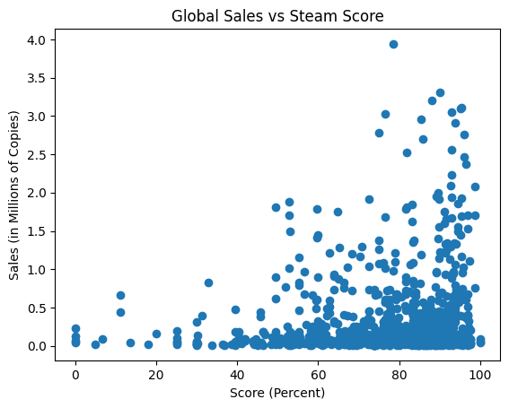

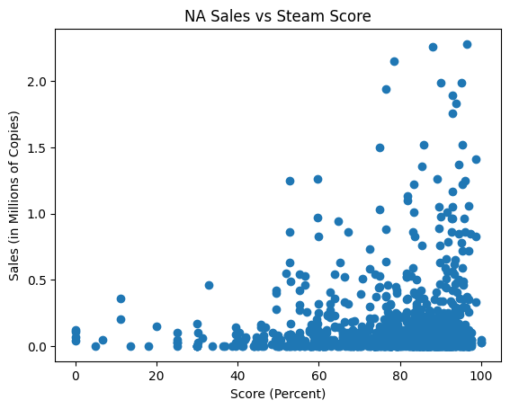

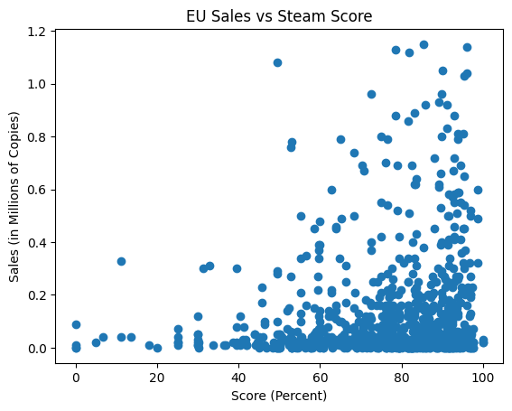

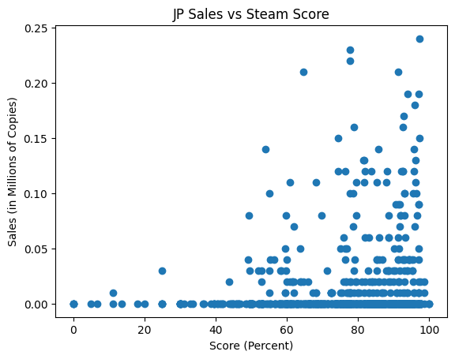

```python
#Remove outliers using percentiles
df2 = df
q1 = df2['Global_Sales'].quantile(0.01)
q99 = df2['Global_Sales'].quantile(0.99)
df2 = df2[(df2['Global_Sales'] >= q1) & (df2['Global_Sales'] <= q99)]
q1 = df2['NA_Sales'].quantile(0.01)
q99 = df2['NA_Sales'].quantile(0.99)
df2 = df2[(df2['NA_Sales'] >= q1) & (df2['NA_Sales'] <= q99)]
q1 = df2['EU_Sales'].quantile(0.01)
q99 = df2['EU_Sales'].quantile(0.99)
df2= df2[(df2['EU_Sales'] >= q1) & (df2['EU_Sales'] <= q99)]
q1 = df2['JP_Sales'].quantile(0.01)
q99 = df2['JP_Sales'].quantile(0.99)
df2= df2[(df2['JP_Sales'] >= q1) & (df2['JP_Sales'] <= q99)]

#Plot global information
plt.scatter(df2['Steam_Score'], df2['Global_Sales'])
plt.ylabel('Sales (in Millions of Copies)')
plt.xlabel('Score (Percent)')
plt.title('Global Sales vs Steam Score')
plt.show()

#Plot NA information
plt.scatter(df2['Steam_Score'], df2['NA_Sales'])
plt.ylabel('Sales (in Millions of Copies)')
plt.xlabel('Score (Percent)')
plt.title('NA Sales vs Steam Score')
plt.show()

#Plot EU information
plt.scatter(df2['Steam_Score'], df2['EU_Sales'])
plt.ylabel('Sales (in Millions of Copies)')
plt.xlabel('Score (Percent)')
plt.title('EU Sales vs Steam Score')
plt.show()

#Plot JP information
plt.scatter(df2['Steam_Score'], df2['JP_Sales'])
plt.ylabel('Sales (in Millions of Copies)')
plt.xlabel('Score (Percent)')
plt.title('JP Sales vs Steam Score')
plt.show()
```

Once the outliers are removed the relationship between Sales and Score becomes much clearer. There is a direct relationship between score and sales. Which makes sense the higher a game is rated the better it will sell. Based on the graphs we can conclude that a games score should be considered when training our model. Next we need to get an understanding of how things have changed over time. To do this we will plot the average sales per year for every region.

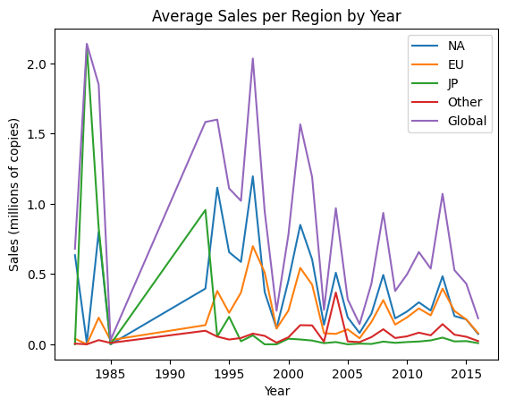

```python
#Calculate the average sales per year.
region_sales_by_year = df.groupby('Year')[['NA_Sales', 'EU_Sales', 'JP_Sales', 'Other_Sales', 'Global_Sales']].mean()

# plot the average sales for each region over time
plt.plot(region_sales_by_year.index, region_sales_by_year['NA_Sales'], label='NA')
plt.plot(region_sales_by_year.index, region_sales_by_year['EU_Sales'], label='EU')
plt.plot(region_sales_by_year.index, region_sales_by_year['JP_Sales'], label='JP')
plt.plot(region_sales_by_year.index, region_sales_by_year['Other_Sales'], label='Other')
plt.plot(region_sales_by_year.index, region_sales_by_year['Global_Sales'], label='Global')

# set the title and labels
plt.title('Average Sales per Region by Year')
plt.xlabel('Year')
plt.ylabel('Sales (millions of copies)')
plt.legend()

# show the plot
plt.show()
```

Based on this line graph we can see that NA Sales make up a large portion of global sales based on the observation that both lines have a very similar shape, this trend decreases over time with the other regions influencing the global sales more. Additionally the average sales appear to be decreasing over time.

Next I want the effects being multiplayer has on a game. In order to judge the effects I will create plots for sales and score for multiplayer games and non-multiplayer games.

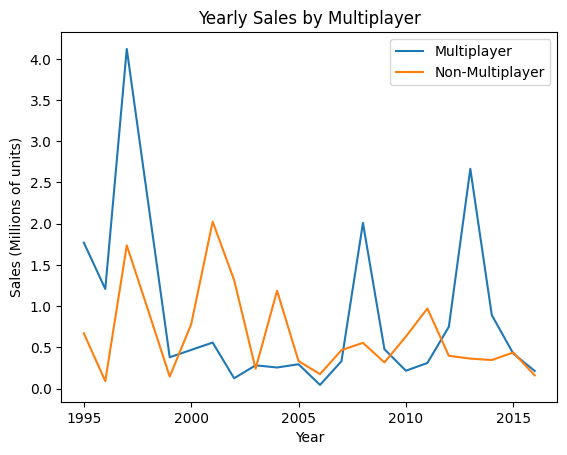

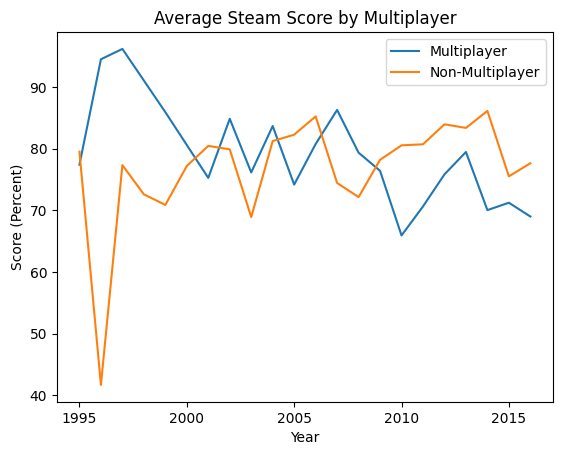

```python
#Create plot comparing sales for multiplayer and non-multiplayer games
mult_sales = df[df['multiplayer']==True].groupby('Year')['Global_Sales'].mean()
non_mult_sales = df[df['multiplayer']==False].groupby('Year')['Global_Sales'].mean()
mult_sales = mult_sales.loc[mult_sales.index >= 1995]
non_mult_sales = non_mult_sales.loc[non_mult_sales.index >= 1995]

plt.plot(mult_sales.index, mult_sales.values, label='Multiplayer')
plt.plot(non_mult_sales.index, non_mult_sales.values, label='Non-Multiplayer')

plt.title('Yearly Sales by Multiplayer')
plt.xlabel('Year')
plt.ylabel('Sales (Millions of units)')
plt.legend()
plt.show()

#Create plot comparing scores for multiplayer and non-multiplayer games
mult_score = df[df['multiplayer']==True].groupby('Year')['Steam_Score'].mean()
non_mult_score = df[df['multiplayer']==False].groupby('Year')['Steam_Score'].mean()
mult_score = mult_score.loc[mult_score.index >= 1995]
non_mult_score = non_mult_score.loc[non_mult_score.index >= 1995]

plt.plot(mult_score.index, mult_score.values, label='Multiplayer')
plt.plot(non_mult_score.index, non_mult_score.values, label='Non-Multiplayer')

plt.title('Average Steam Score by Multiplayer')
plt.xlabel('Year')
plt.ylabel('Score (Percent)')
plt.legend()
plt.show()
```

From these graphs we can see that whether or not a game is multiplayer does not have a clear effect on a game's score or sales.

Next lets look at sales vs average playtime and score vs average play time. To do this we will use a similar method to create the scatterplot for sales vs score.

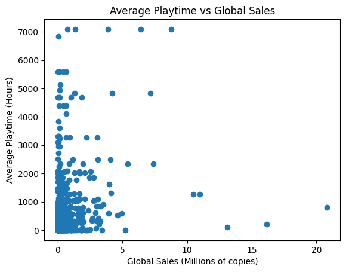

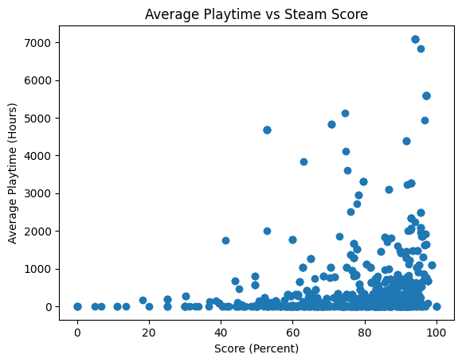

```python
#Remove average_playtime outliers
df3 = df
q1 = df3['average_playtime'].quantile(0.01)
q99 = df3['average_playtime'].quantile(0.99)
df3 = df3[(df3['average_playtime'] >= q1) & (df3['average_playtime'] <= q99)]

#Create Average Playtime vs Global Sales plot
plt.scatter(df3['Global_Sales'], df3['average_playtime'])
plt.ylabel('Average Playtime (Hours)')
plt.xlabel('Global Sales (Millions of copies)')
plt.title('Average Playtime vs Global Sales')
plt.show()

#Create Average Playtime vs Steam Score plot
plt.scatter(df3['Steam_Score'], df3['average_playtime'])
plt.ylabel('Average Playtime (Hours)')
plt.xlabel('Score (Percent)')
plt.title('Average Playtime vs Steam Score')
plt.show()
```

Based on these graphs the Average Playtime statistic does not have a meaningful relationship with global sales but average playtime tends to increase as a game's Steam score increases. Again this makes sense if a game is good it will receive a high score and people will play it longer. However, shorter games that people do not play for as long can still sell well. Based on the relationship average playtime has with sales we should not include it when we are training our model.

Who made the game is a huge factor in everything about the game including the sales. So next we will want to look at the developers to see if there are any developers who produce games that have high sales consistently. Now there are a lot of Steam developers, so to get better results we will only look at the top 50 developers who have made more than three games.

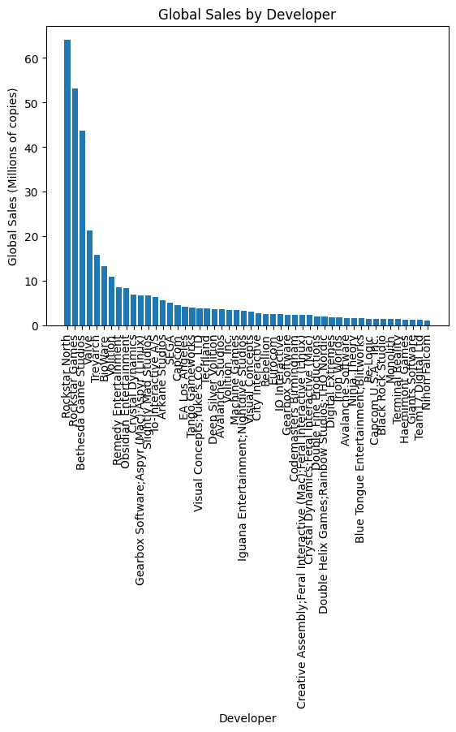

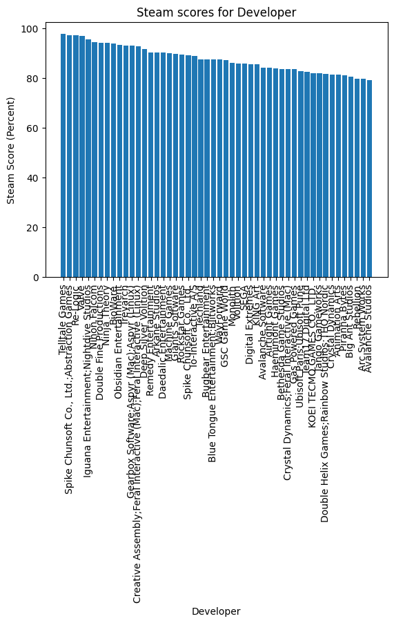

```python
#Count the number of games made by each developer
count = df.groupby('developer')['name'].count()
dev = count[count > 3].index.tolist()

#Group developer with the statistic of interest
dev_sale = df.groupby('developer')['Global_Sales'].sum().reset_index()
dev_score = df.groupby('developer')['Steam_Score'].mean().reset_index()

#Sort in acending order to get developer ranks for sales and score
dev_sale = dev_sale.sort_values('Global_Sales', ascending=False).reset_index(drop=True)
dev_score = dev_score.sort_values('Steam_Score', ascending=False).reset_index(drop=True)

#Remove developers who made less than 3 games and store in separate location
#because developer ranks will be needed later
dev_sales = dev_sale[dev_sale['developer'].isin(dev)][:50]
dev_scores = dev_score[dev_score['developer'].isin(dev)][:50]

#Plot results
plt.bar(dev_sales['developer'], dev_sales['Global_Sales'])
plt.xticks(rotation=90)
plt.title('Global Sales by Developer')
plt.xlabel('Developer')
plt.ylabel('Global Sales (Millions of copies)')
plt.show()

plt.bar(dev_scores['developer'], dev_scores['Steam_Score'])
plt.xticks(rotation=90)
plt.title('Steam scores for Developer')
plt.xlabel('Developer')
plt.ylabel('Steam Score (Percent)')
plt.show()
```

Next we will do the same thing we did for the developer for the game's publisher.

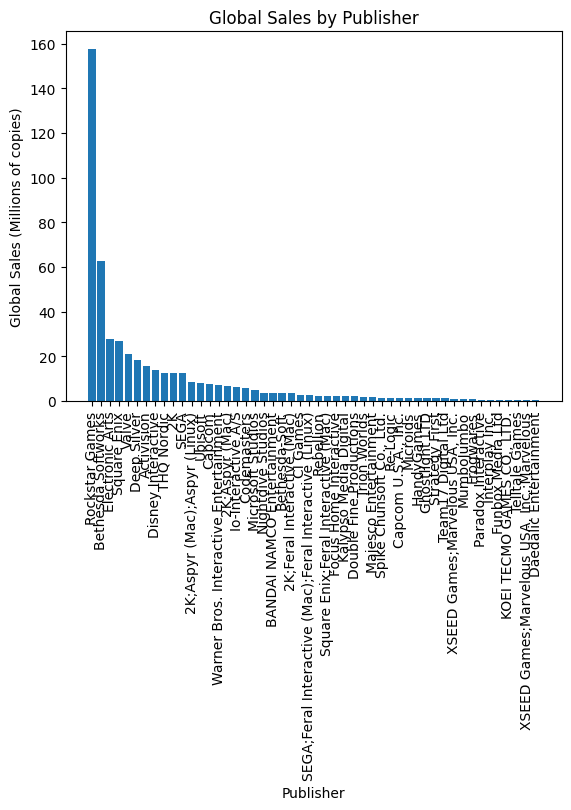

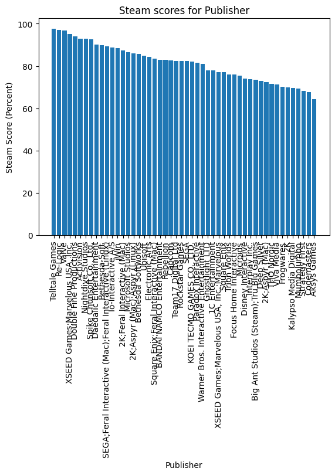

```python
#Count the number of games published by each publisher
count = df.groupby('publisher')['name'].count()
pub = count[count > 3].index.tolist()

#Group developer with the statistic of interest
pub_sale = df.groupby('publisher')['Global_Sales'].sum().reset_index()
pub_score = df.groupby('publisher')['Steam_Score'].mean().reset_index()

#Sort in acending order to get publisher ranks
pub_sale = pub_sale.sort_values('Global_Sales', ascending=False).reset_index(drop=True)
pub_score = pub_score.sort_values('Steam_Score', ascending=False).reset_index(drop=True)

#Remove publishers who made less than 3 games and store in separate location
#because publisher ranks will be needed later
pub_sales = pub_sale[pub_sale['publisher'].isin(pub)][:50]
pub_scores = pub_score[pub_score['publisher'].isin(pub)][:50]


#Plot results
plt.bar(pub_sales['publisher'], pub_sales['Global_Sales'])
plt.xticks(rotation=90)
plt.title('Global Sales by Publisher')
plt.xlabel('Publisher')
plt.ylabel('Global Sales (Millions of copies)')
plt.show()

plt.bar(pub_scores['publisher'], pub_scores['Steam_Score'])
plt.xticks(rotation=90)
plt.title('Steam scores for Publisher')
plt.xlabel('Publisher')
plt.ylabel('Steam Score (Percent)')
plt.show()
```

From these graphs, we can see that a games publisher has a similar impact on a game's sales to a game's developer. We learned from these four graphs that we should include the game's publisher and developer data when training our model.

**Analysis, hypothesis testing, and ML**

Now we are on to the fourth stage of the data science pipeline. This is where we bring everything together. We have identified the variables we need to use to train our model. Those variables are price, steam_score, developer, and publisher.

In order to properly use the publisher and developer data for training a neural network we are going to give each publisher and developer two ranks. These are the sales and score ranks. For example a game with a developer sale rank of 1 means that it's developer has the highest sales out of all of the developers.

```python
#Reuse the series from the developer and publisher analysis
dev_sale['dev_sale_rank'] = dev_sale.index + 1
dev_score['dev_score_rank'] = dev_score.index + 1
pub_sale['pub_sale_rank'] = pub_sale.index + 1
pub_score['pub_score_rank'] = pub_score.index + 1

#Add the new rank columns to the master dataframe
df = df.merge(dev_sale[['developer', 'dev_sale_rank']], on = 'developer', how = 'left')
df = df.merge(dev_score[['developer', 'dev_score_rank']], on = 'developer', how = 'left')
df = df.merge(pub_sale[['publisher', 'pub_sale_rank']], on = 'publisher', how = 'left')
df = df.merge(pub_score[['publisher', 'pub_score_rank']], on = 'publisher', how = 'left')
df.head()
```

|  | appid | name | release_date | english | developer | publisher | required_age | categories | genres | achievements | ... | multiplayer | windows | mac | linux | Steam_Score | Steam_Count | dev_sale_rank | dev_score_rank | pub_sale_rank | pub_score_rank |
| --- | --- | --- | --- | --- | --- | --- | --- | --- | --- | --- | --- | --- | --- | --- | --- | --- | --- | --- | --- | --- | --- |
| 0 | 10 | Counter-Strike | 2000-11-01 00:00:00 | 1 | Valve | Valve | 0 | Multi-player;Online Multi-Player;Local Multi-P... | Action | 0 | ... | True | True | True | True | 97.388815 | 127873 | 5 | 8 | 5 | 6 |
| 1 | 70 | Half-Life | 1998-11-08 00:00:00 | 1 | Valve | Valve | 0 | Single-player;Multi-player;Online Multi-Player... | Action | 0 | ... | True | True | True | True | 96.187836 | 28855 | 5 | 8 | 5 | 6 |
| 2 | 70 | Half-Life | 1998-11-08 00:00:00 | 1 | Valve | Valve | 0 | Single-player;Multi-player;Online Multi-Player... | Action | 0 | ... | True | True | True | True | 96.187836 | 28855 | 5 | 8 | 5 | 6 |
| 3 | 220 | Half-Life 2 | 2004-11-16 00:00:00 | 1 | Valve | Valve | 0 | Single-player;Steam Achievements;Steam Trading... | Action | 33 | ... | False | True | True | True | 96.560060 | 70321 | 5 | 8 | 5 | 6 |
| 4 | 220 | Half-Life 2 | 2004-11-16 00:00:00 | 1 | Valve | Valve | 0 | Single-player;Steam Achievements;Steam Trading... | Action | 33 | ... | False | True | True | True | 96.560060 | 70321 | 5 | 8 | 5 | 6 |

5 rows × 31 columns

Each game has a list of tags that provide users with information about the game. We will want to use that information to train the model as well. The game's tags are stored in the categories column as a long string. This is an issue because we can't simply use that to train our model. In order to use the tags we will need to create a dataframe of indicator variables for the categories column. This is simply a dataframe with columns for each tag and a 1 or a 0 in that column indicating if a game has that tag. Then I will concatenate that dataframe with the other variables that will be used to train the model.

```python
#Create dataframe of indicator variables
tags = df['categories'].str.get_dummies(';')
tags.head()
```

|  | Captions available | Co-op | Commentary available | Cross-Platform Multiplayer | Full controller support | In-App Purchases | Includes Source SDK | Includes level editor | Local Co-op | Local Multi-Player | ... | Single-player | Stats | Steam Achievements | Steam Cloud | Steam Leaderboards | Steam Trading Cards | Steam Turn Notifications | Steam Workshop | VR Support | Valve Anti-Cheat enabled |
| --- | --- | --- | --- | --- | --- | --- | --- | --- | --- | --- | --- | --- | --- | --- | --- | --- | --- | --- | --- | --- | --- |
| 0 | 0 | 0 | 0 | 0 | 0 | 0 | 0 | 0 | 0 | 1 | ... | 0 | 0 | 0 | 0 | 0 | 0 | 0 | 0 | 0 | 1 |
| 1 | 0 | 0 | 0 | 0 | 0 | 0 | 0 | 0 | 0 | 0 | ... | 1 | 0 | 0 | 1 | 0 | 0 | 0 | 0 | 0 | 1 |
| 2 | 0 | 0 | 0 | 0 | 0 | 0 | 0 | 0 | 0 | 0 | ... | 1 | 0 | 0 | 1 | 0 | 0 | 0 | 0 | 0 | 1 |
| 3 | 1 | 0 | 0 | 0 | 0 | 0 | 1 | 0 | 0 | 0 | ... | 1 | 0 | 1 | 1 | 0 | 1 | 0 | 0 | 0 | 0 |
| 4 | 1 | 0 | 0 | 0 | 0 | 0 | 1 | 0 | 0 | 0 | ... | 1 | 0 | 1 | 1 | 0 | 1 | 0 | 0 | 0 | 0 |

5 rows × 26 columns

Then what we need to do is join the tags with the other variables to form the dataset that will be used to train the model. We can accomplish this by using the concat function from the pandas library.

```python
#Concatenate all variables together for the training data
X = pd.concat([df[['price', 'Steam_Score', 'dev_sale_rank', 'dev_score_rank', 'pub_sale_rank', 'dev_score_rank']], tags], axis=1)
y = df[['Global_Sales', 'NA_Sales', 'EU_Sales', 'JP_Sales', 'Other_Sales']]

#Split the data into test sets and validation sets
X_train, X_val, y_train, y_val = train_test_split(X, y, test_size=0.2, random_state=42)
```

Now that we have the data to train our model, we have to define the model itself. When defining the model we have to consider the data we will be feeding into our model. So let's print out the shape of X to see what we are dealing with.

```python
print(X.shape[1])
```

```
32
```

The model we will be using is based on the Sequential model from the Tensorflow Keras library. More information on sequential models can be found here, https://www.tensorflow.org/guide/keras/sequential_model. Based on the shape of X, we can see that there are 32 input variables so the input layer should have 32 nodes. Similarly we want to get 5 variables out of our model (One for each of our regions) so our output layer should have 5 nodes. The number of nodes in the hidden layer simply has to be between the number of nodes in the input and output layers.

```python
# Define the architecture of the neural network
model = Sequential()
model.add(Dense(32, activation='relu', input_dim=X_train.shape[1])) #Input layer
model.add(Dense(15, activation='relu')) #Hidden layer
model.add(Dense(5, activation='linear')) #Output layer

# Compile the model
model.compile(loss='mean_squared_error', optimizer='adam', metrics=['accuracy'])
```

Now that the model is defined we need to fit our data to the model. This is easy because Tensorflow deals with all of the heavy lifting for us.

```python
# Train the model
history = model.fit(X_train, y_train, validation_data=(X_val, y_val), epochs=100, batch_size=32)
```

For curiosity's sake we can see how the loss and accuracy of model changes as it is training. To do this we can the history object which is the output of Tensorflow's fit function.

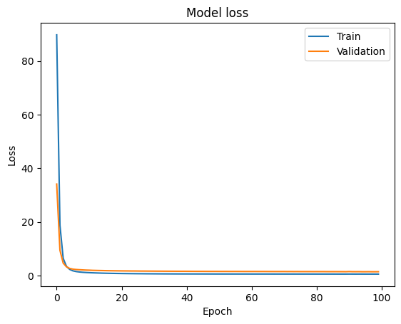

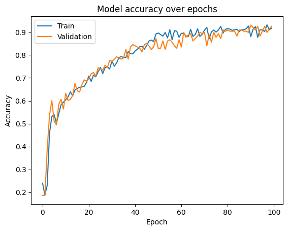

```python
#Plot the loss over epochs
plt.plot(history.history['loss'])
plt.plot(history.history['val_loss'])
plt.title('Model loss')
plt.ylabel('Loss')
plt.xlabel('Epoch')
plt.legend(['Train', 'Validation'], loc='upper right')
plt.show()

#Plot the accuracy over epochs
plt.plot(history.history['accuracy'])
plt.plot(history.history['val_accuracy'])
plt.title('Model accuracy over epochs')
plt.ylabel('Accuracy')
plt.xlabel('Epoch')
plt.legend(['Train', 'Validation'], loc='upper left')
plt.show()
```

Alright, the model has been trained and now it is time to see how good the model actually is at predicting the sales of a Steam Game. We can evaluate the model using the evaluate function from the Tensorflow library.

```python
# Evaluate the model
loss, acc = model.evaluate(X_val, y_val)
print('Accuracy:', acc)
```

```
Accuracy: 0.9255319237709045
```

**Insight and Policy Decision**

By the end of this tutorial, I hope that you have learned about the data science pipeline and machine learning. From analyzing Steam game data we learned that:

- NA sales are the largest contributor to steam sales globally.
- Average annual sales are decreasing globally.
- Multiplayer games do not automatically sell better because they are multiplayer

This tutorial barely scraped the surface of what is possible with data science. As computers get faster and faster we will be able to train more advanced and complex models that will be able to more accurately make predictions and solve problems.